# Dataset.05: Container Pre-Marshalling Problem

This is an extension of the 2013 premarshalling dataset that includes more features and a set of test instances.

There are three sets of features:

- feature_values.arff contains the full set of features from iteration 2 of our latent feature analysis (LFA) process (see paper) feature_values_itr1.arff contains only the features after iteration 1 of LFA feature_values_orig.arff containers the features used in PREMARHSALLING-ASTAR-2013
- We also provide test data with an identical naming scheme (see _test).
- The features for the pre-marshalling problem are all extremely easy and fast to compute, thus the feature_costs.arff file has been omitted, as it would be time 0 for every feature (regardless of using original, iteration 1 or iteration 2 features).

```python
import pandas as pd

# data (as pandas dataframes)
X = pd.read_parquet('cpmp.pq').drop(columns = ['runtime'])
y = pd.read_parquet('cpmp.pq')['runtime']
```

```python
print(len(X.columns))
```

```
26
```

There are 26 features in data.

```python
print(y.value_counts())
```

```
runtime
3600.000    582
0.004        67
0.008        12
0.016        11
0.036        10
           ...
16.273        1
6.432         1
6.104         1
0.204         1
74.453        1
Name: count, Length: 1161, dtype: int64
```

```python
X.info()
```

```
<class 'pandas.core.frame.DataFrame'>
RangeIndex: 2108 entries, 0 to 2107
Data columns (total 26 columns):
 #   Column                       Non-Null Count  Dtype
---  ------                       --------------  -----
 0   instance_id                  2108 non-null   object
 1   repetition                   2108 non-null   uint8
 2   stacks                       2108 non-null   uint8
 3   tiers                        2108 non-null   uint8
 4   stack.tier.ratio             2108 non-null   float64
 5   container.density            2108 non-null   float64
 6   empty.stack.pct              2108 non-null   float64
 7   overstowing.stack.pct        2108 non-null   float64
 8   overstowing.2cont.stack.pct  2108 non-null   float64
 9   group.same.min               2108 non-null   uint8
```

[output cut: 18 more lines]

```python
X.describe()
```

|  | repetition | stacks | tiers | stack.tier.ratio | container.density | empty.stack.pct | overstowing.stack.pct | overstowing.2cont.stack.pct | group.same.min | group.same.max | ... | top.good.max | top.good.mean | top.good.stdev | overstowage.pct | bflb | left.density | tier.weighted.groups | avg.l1.top.left.lg.group | cont.empty.grt.estack | pct.bottom.pct.on.top |
| --- | --- | --- | --- | --- | --- | --- | --- | --- | --- | --- | --- | --- | --- | --- | --- | --- | --- | --- | --- | --- | --- |
| count | 2108.0 | 2108.000000 | 2108.000000 | 2108.000000 | 2108.000000 | 2108.000000 | 2108.000000 | 2108.000000 | 2108.000000 | 2108.000000 | ... | 2108.000000 | 2108.000000 | 2108.000000 | 2108.000000 | 2108.000000 | 2108.000000 | 2108.000000 | 2108.000000 | 2108.000000 | 2108.00000 |
| mean | 1.0 | 11.548387 | 5.874763 | 0.736708 | 0.681446 | 0.065979 | 0.850599 | 0.953640 | 0.493359 | 3.658444 | ... | 15.286528 | 7.651367 | 4.390874 | 0.431155 | 30.203036 | 0.322497 | 0.461425 | 0.609302 | 0.087654 | 0.13081 |
| std | 0.0 | 5.986937 | 0.911597 | 0.478441 | 0.069840 | 0.111322 | 0.155872 | 0.079766 | 0.500075 | 2.898871 | ... | 6.112959 | 2.692406 | 1.944374 | 0.078005 | 13.800895 | 0.143689 | 0.052901 | 0.146964 | 0.139033 | 0.15232 |
| min | 1.0 | 4.000000 | 5.000000 | 0.250000 | 0.600000 | 0.000000 | 0.500000 | 0.583333 | 0.000000 | 1.000000 | ... | 5.000000 | 3.000000 | 0.780625 | 0.214286 | 8.000000 | 0.000000 | 0.311574 | 0.216667 | 0.000000 | 0.00000 |
| 25% | 1.0 | 6.000000 | 5.000000 | 0.312500 | 0.600000 | 0.000000 | 0.714286 | 0.923077 | 0.000000 | 1.000000 | ... | 10.000000 | 5.600000 | 2.812420 | 0.366667 | 18.000000 | 0.285714 | 0.432854 | 0.500000 | 0.000000 | 0.00000 |
| 50% | 1.0 | 12.000000 | 6.000000 | 0.500000 | 0.666667 | 0.000000 | 0.875000 | 1.000000 | 0.000000 | 4.000000 | ... | 14.000000 | 7.142860 | 4.060760 | 0.450000 | 29.000000 | 0.323741 | 0.471799 | 0.611111 | 0.000000 | 0.06250 |
| 75% | 1.0 | 16.000000 | 7.000000 | 1.000000 | 0.714286 | 0.100000 | 1.000000 | 1.000000 | 1.000000 | 6.000000 | ... | 19.000000 | 9.400000 | 5.648870 | 0.480000 | 41.000000 | 0.359712 | 0.496000 | 0.705882 | 0.162500 | 0.20000 |
| max | 1.0 | 20.000000 | 8.000000 | 1.750000 | 0.800000 | 0.400000 | 1.000000 | 1.000000 | 1.000000 | 14.000000 | ... | 36.000000 | 16.785700 | 11.508100 | 0.600000 | 72.000000 | 0.856115 | 0.598757 | 0.958333 | 0.400000 | 0.75000 |

8 rows × 23 columns

```python
X.describe(include = ['object', 'category'])
```

|  | instance_id | algorithm | runstatus |
| --- | --- | --- | --- |
| count | 2108 | 2108 | 2108 |
| unique | 527 | 4 | 3 |
| top | BF1_cpmp_16_5_48_10_29_1 | astar.symmulgt.transmul | ok |
| freq | 4 | 527 | 1526 |

```python
X.drop(columns = 'instance_id', inplace = True)
```

Categorical features will be dummied.

```python
X_df = pd.concat([X.drop(columns = ['algorithm', 'runstatus']), pd.get_dummies(X[['algorithm', 'runstatus']])], axis = 1)
```

```python
from sklearn.model_selection import train_test_split

X_train,X_test,y_train,y_test = train_test_split(X_df,y,test_size=0.3)
```

```python
from sklearn.preprocessing import StandardScaler
scaler = StandardScaler()
X_train = scaler.fit_transform(X_train)
X_test = scaler.transform(X_test)
```

## kNN

```python
import numpy as np
from sklearn.neighbors import KNeighborsRegressor
```

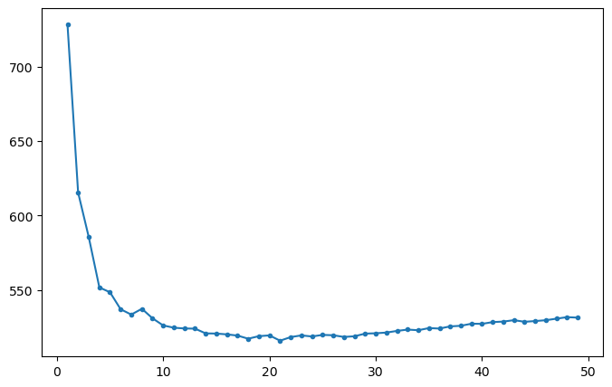

```python
import matplotlib.pyplot as plt
error_rate = []

for i in range(1,50):
    knn = KNeighborsRegressor(n_neighbors=i)
    knn.fit(X_train, y_train.values.ravel())
    y_pred_knn = knn.predict(X_test)
    error_rate.append(np.sqrt(mean_squared_error(y_test, y_pred_knn)))

plt.figure(figsize=(8,5))
plt.plot(range(1,50),error_rate, marker='o', markersize=3)
```

I selected 18 as n_neighbors.

```python
knn = KNeighborsRegressor(n_neighbors=18)
knn.fit(X_train, y_train.values.ravel())
y_pred_knn = knn.predict(X_test)
np.sqrt(mean_squared_error(y_test, y_pred_knn))
```

```
517.1795447290824
```

## Decision Trees

```python
from sklearn.tree import DecisionTreeRegressor
```

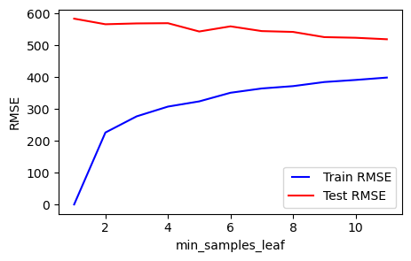

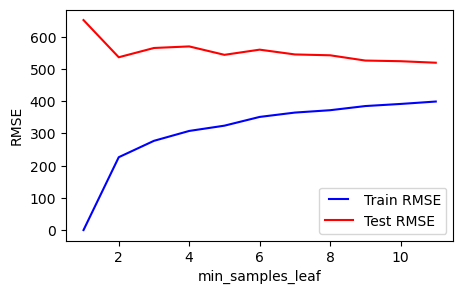

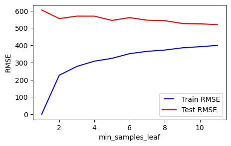

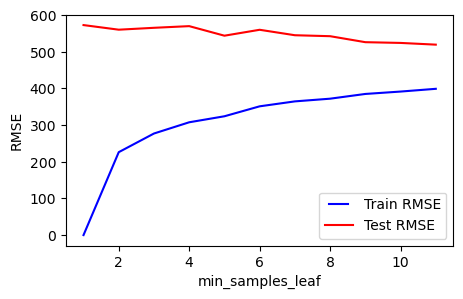

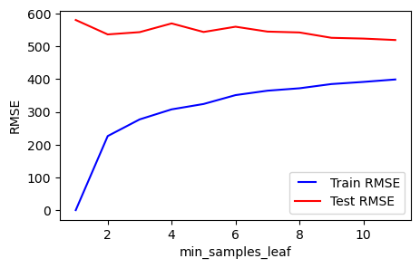

```python
min_samples_leafs = np.linspace(1, 11, 11, dtype = int,endpoint=True)

for i in range(5):
    error_train = []
    error_test = []
    for min_samples_leaf in min_samples_leafs:
        dt = DecisionTreeRegressor(min_samples_leaf=min_samples_leaf)
        dt.fit(X_train, y_train.values.ravel())
        y_pred_dt_test = dt.predict(X_test)
        y_pred_dt_train = dt.predict(X_train)
        rmse_train = np.sqrt(mean_squared_error(y_train, y_pred_dt_train))
        error_train.append(rmse_train)
        rmse_test = np.sqrt(mean_squared_error(y_test, y_pred_dt_test))
        error_test.append(rmse_test)

    from matplotlib.legend_handler import HandlerLine2D
    plt.figure(figsize=(5, 3))
    line1, = plt.plot(min_samples_leafs, error_train, 'b', label='Train RMSE')
    line2, = plt.plot(min_samples_leafs, error_test, 'r', label='Test RMSE')
    plt.legend(handler_map={line1: HandlerLine2D(numpoints=2)})
    plt.ylabel('RMSE')
    plt.xlabel('min_samples_leaf')
    plt.show()
```

I will select 2.

```python
dt = DecisionTreeRegressor(min_samples_leaf=2)
dt = dt.fit(X_train, y_train)
y_pred_dt = dt.predict(X_test)
np.sqrt(mean_squared_error(y_test, y_pred_dt))
```

```
540.3947655124117
```

## Random Forests

```python
from sklearn.ensemble import RandomForestRegressor
from sklearn.metrics import mean_squared_error
```

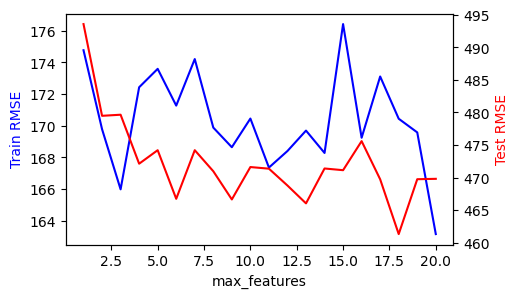

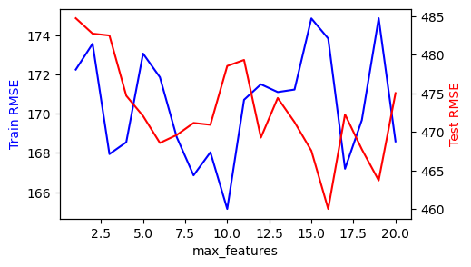

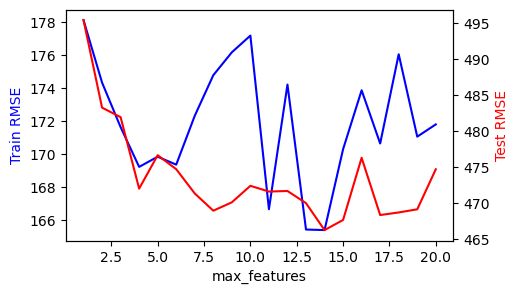

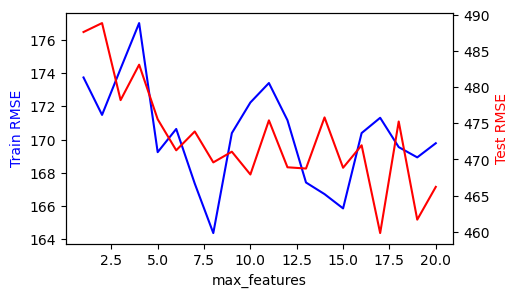

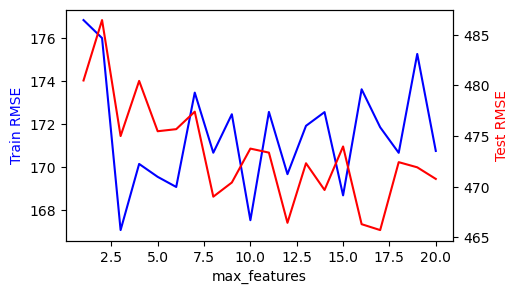

```python
max_features_n = np.linspace(1, 20, 20, dtype = int,endpoint=True) #57/3 = 19

for i in range(5):
    error_train = []
    error_test = []
    for max_features in max_features_n:
        rf = RandomForestRegressor(max_features = max_features)
        rf.fit(X_train, y_train.values.ravel())
        y_pred_rf_test = rf.predict(X_test)
        y_pred_rf_train = rf.predict(X_train)
        rmse_train = np.sqrt(mean_squared_error(y_train, y_pred_rf_train))
        error_train.append(rmse_train)
        rmse_test = np.sqrt(mean_squared_error(y_test, y_pred_rf_test))
        error_test.append(rmse_test)

    fig, ax1 = plt.subplots(figsize=(5, 3))

    ax2 = ax1.twinx()
    ax2.plot(max_features_n, error_test, 'r', label='Test RMSE')
    ax1.plot(max_features_n, error_train, 'b', label='Train RMSE')

    ax1.set_xlabel('max_features')
    ax2.set_ylabel('Test RMSE', color='r')
    ax1.set_ylabel('Train RMSE', color='b')

    plt.show()
```

My selection of max_features will be 7.

```python
rf = RandomForestRegressor(max_features = 7)
rf = rf.fit(X_train, y_train.values.ravel())
y_pred_rf = rf.predict(X_test)
np.sqrt(mean_squared_error(y_test, y_pred_rf))
```

```
472.60215435953427
```

## Gradient Boosted Trees

```python
from sklearn.ensemble import GradientBoostingClassifier
from xgboost import XGBRegressor
```

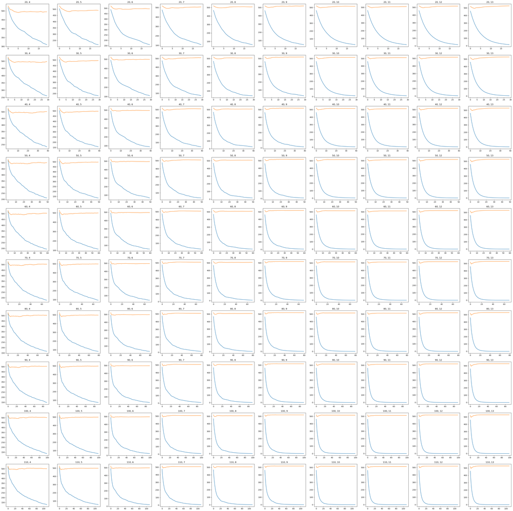

```python
fig, axs = plt.subplots(10, 10, figsize=(50, 50))
for i in range(10):
    for j in range(10):
        model = XGBRegressor(n_estimators = 20+10*i, max_depth = 4+j)
        evalset = [(X_train, y_train), (X_test,y_test)]
        model.fit(X_train, y_train, eval_set=evalset, verbose=False)
        model.set_params(eval_metric = 'logloss')
        y_pred_xgb = model.predict(X_test)
        score = np.sqrt(mean_squared_error(y_test, y_pred_xgb))
        results = model.evals_result()

        axs[i, j].plot(results['validation_0']['rmse'], label='train')
        axs[i, j].plot(results['validation_1']['rmse'], label='test')
        axs[i, j].set_title(str(20+10*i) + ', ' + str(4+j))
```

```python
xgb = XGBRegressor(n_estimators = 20, max_depth = 6)
xgb.fit(X_train, y_train)
y_pred_xgb = xgb.predict(X_test)
np.sqrt(mean_squared_error(y_test, y_pred_xgb))
```

```
495.27975380485697
```

## Cross-validation

```python
from sklearn.model_selection import KFold
from sklearn.model_selection import cross_val_score
from numpy import mean
from numpy import absolute
from numpy import sqrt
cv = KFold(n_splits=10, random_state=1, shuffle=True)
for clf in [knn, dt, rf, xgb]:
    scores = cross_val_score(clf, X_df, y, scoring='neg_mean_absolute_error', cv=cv, n_jobs=-1)
    print(clf, ' : ', mean(absolute(scores)))
```

```
KNeighborsRegressor(n_neighbors=18)  :  248.33864299535608
DecisionTreeRegressor(min_samples_leaf=2)  :  229.1096406816162
RandomForestRegressor(max_features=7)  :  209.69586275739593
XGBRegressor(base_score=None, booster=None, callbacks=None,
             colsample_bylevel=None, colsample_bynode=None,
             colsample_bytree=None, device=None, early_stopping_rounds=None,
             enable_categorical=False, eval_metric=None, feature_types=None,
             gamma=None, grow_policy=None, importance_type=None,
             interaction_constraints=None, learning_rate=None, max_bin=None,
             max_cat_threshold=None, max_cat_to_onehot=None,
             max_delta_step=None, max_depth=6, max_leaves=None,
             min_child_weight=None, missing=nan, monotone_constraints=None,
             multi_strategy=None, n_estimators=20, n_jobs=None,
             num_parallel_tree=None, random_state=None, ...)  :  223.50404413962914
```

## Conclusion

```python
for clf in [[knn, y_pred_knn], [dt, y_pred_dt], [rf, y_pred_rf], [xgb, y_pred_xgb]]:
    print(clf[0], ' : ', np.sqrt(mean_squared_error(y_test, clf[1])))
```

```
KNeighborsRegressor(n_neighbors=18)  :  517.1795447290824
DecisionTreeRegressor(min_samples_leaf=2)  :  540.3947655124117
RandomForestRegressor(max_features=7)  :  472.60215435953427
XGBRegressor(base_score=None, booster=None, callbacks=None,
             colsample_bylevel=None, colsample_bynode=None,
             colsample_bytree=None, device=None, early_stopping_rounds=None,
             enable_categorical=False, eval_metric=None, feature_types=None,
             gamma=None, grow_policy=None, importance_type=None,
             interaction_constraints=None, learning_rate=None, max_bin=None,
             max_cat_threshold=None, max_cat_to_onehot=None,
             max_delta_step=None, max_depth=6, max_leaves=None,
             min_child_weight=None, missing=nan, monotone_constraints=None,
             multi_strategy=None, n_estimators=20, n_jobs=None,
             num_parallel_tree=None, random_state=None, ...)  :  495.27975380485697
```

Accuracy scores and KFold CV scores led me to choose RF.

- its accuracy score is higher
- its CV score is the lowest